# Stat 214 project

Emmanuel Oluloto

April 19, 2018

## DATASET

I’m working with a table that contains stats for video game sales obtained from Kaggle : https://www.kaggle.com/rush4ratio/video-game-sales-with-ratings

```r
colnames(GameSales_Clean.df)
```

```
##  [1] "Name"            "Platform"        "Year_of_Release"
##  [4] "Genre"           "Publisher"       "NA_Sales"
##  [7] "EU_Sales"        "JP_Sales"        "Other_Sales"
## [10] "Global_Sales"    "Critic_Score"    "Critic_Count"
## [13] "User_Score"      "User_Count"      "Developer"
## [16] "Rating"
```

```r
str(GameSales_Clean.df)
```

```
## Classes 'tbl_df', 'tbl' and 'data.frame':    6947 obs. of  16 variables:
##  $ Name           : chr  "Wii Sports" "Mario Kart Wii" "Wii Sports Resort" "New Super Mario Bros." ...
##  $ Platform       : chr  "Wii" "Wii" "Wii" "DS" ...
##  $ Year_of_Release: chr  "2006" "2008" "2009" "2006" ...
##  $ Genre          : chr  "Sports" "Racing" "Sports" "Platform" ...
##  $ Publisher      : chr  "Nintendo" "Nintendo" "Nintendo" "Nintendo" ...
##  $ NA_Sales       : num  41.4 15.7 15.6 11.3 14 ...
##  $ EU_Sales       : num  28.96 12.76 10.93 9.14 9.18 ...
##  $ JP_Sales       : num  3.77 3.79 3.28 6.5 2.93 4.7 4.13 3.6 0.24 2.53 ...
##  $ Other_Sales    : num  8.45 3.29 2.95 2.88 2.84 2.24 1.9 2.15 1.69 1.77 ...
##  $ Global_Sales   : num  82.5 35.5 32.8 29.8 28.9 ...
##  $ Critic_Score   : int  76 82 80 89 58 87 91 80 61 80 ...
##  $ Critic_Count   : int  51 73 73 65 41 80 64 63 45 33 ...
##  $ User_Score     : chr  "8" "8.3" "8" "8.5" ...
##  $ User_Count     : int  322 709 192 431 129 594 464 146 106 52 ...
##  $ Developer      : chr  "Nintendo" "Nintendo" "Nintendo" "Nintendo" ...
##  $ Rating         : chr  "E" "E" "E" "E" ...
##  - attr(*, "na.action")=Class 'omit'  Named int [1:9772] 2 5 6 10 11 13 19 21 22 23 ...
##   .. ..- attr(*, "names")= chr [1:9772] "2" "5" "6" "10" ...
```

## Research Questions

#### 1. Regression Question (EX - Q, RESP - Q)

How do game sales in Japan change over time, with respect to user score?

Explanatory - Year_of_Release, User_Score* (Quant)  
Response - JP_Sales (millions) (Quant)

MODEL:
$$Y = \beta_0 + \beta_1X_1 + \beta_2X_2 + \beta_3X_1^2 + \beta_4X_2^2 + \epsilon$$
$$Y = \text{Game Sales in Japan}, X_1 = \text{Year of Release}, X_2 = \text{User Score}$$

I used an almost-complete second-order model (minus the interaction). I had to test a LOT of models to find the one that worked best. I decided not to factor in the User Count, as that made the model more complex while not really being significant.

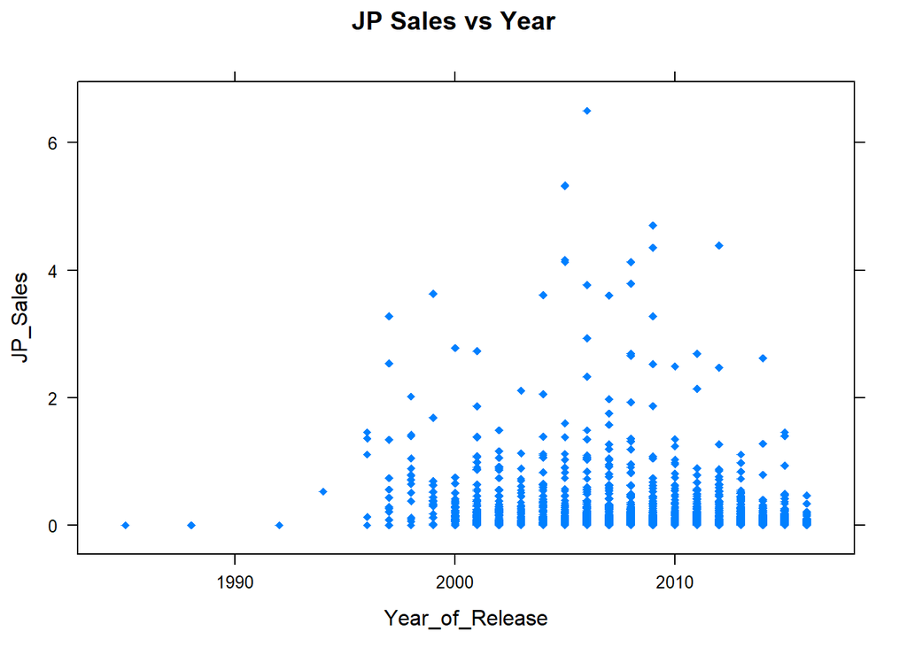

```r
analysis_1 <- Original_Dataset[!(Original_Dataset$Year_of_Release=="N/A"),]
analysis_1 <- Original_Dataset[!(is.na(Original_Dataset$User_Score)),]
#str(analysis_1)

# Change year to numeric
analysis_1$Year_of_Release =  as.numeric(analysis_1$Year_of_Release)
attach(analysis_1)

xyplot(JP_Sales ~ Year_of_Release, main="JP Sales vs Year", pch = 18)
```

```r
# Original Model
JPSales.lm = lm(JP_Sales ~ Year_of_Release + User_Score + I(User_Score^2) + I(Year_of_Release^2))
summary(JPSales.lm)
```

```
##
## Call:
## lm(formula = JP_Sales ~ Year_of_Release + User_Score + I(User_Score^2) +
##     I(Year_of_Release^2))
##
## Residuals:
##     Min      1Q  Median      3Q     Max
## -0.2485 -0.0762 -0.0385 -0.0040  6.4020
##
## Coefficients:
##                        Estimate Std. Error t value Pr(>|t|)
## (Intercept)           1.897e+03  5.823e+02   3.258  0.00113 **
## Year_of_Release      -1.890e+00  5.800e-01  -3.258  0.00113 **
## User_Score           -5.174e-02  1.217e-02  -4.252 2.14e-05 ***
## I(User_Score^2)       6.046e-03  9.764e-04   6.192 6.25e-10 ***
## I(Year_of_Release^2)  4.706e-04  1.444e-04   3.258  0.00113 **
## ---
## Signif. codes:  0 '***' 0.001 '**' 0.01 '*' 0.05 '.' 0.1 ' ' 1
##
## Residual standard error: 0.273 on 7458 degrees of freedom
##   (127 observations deleted due to missingness)
## Multiple R-squared:  0.02303,    Adjusted R-squared:  0.0225
## F-statistic: 43.95 on 4 and 7458 DF,  p-value: < 2.2e-16
```

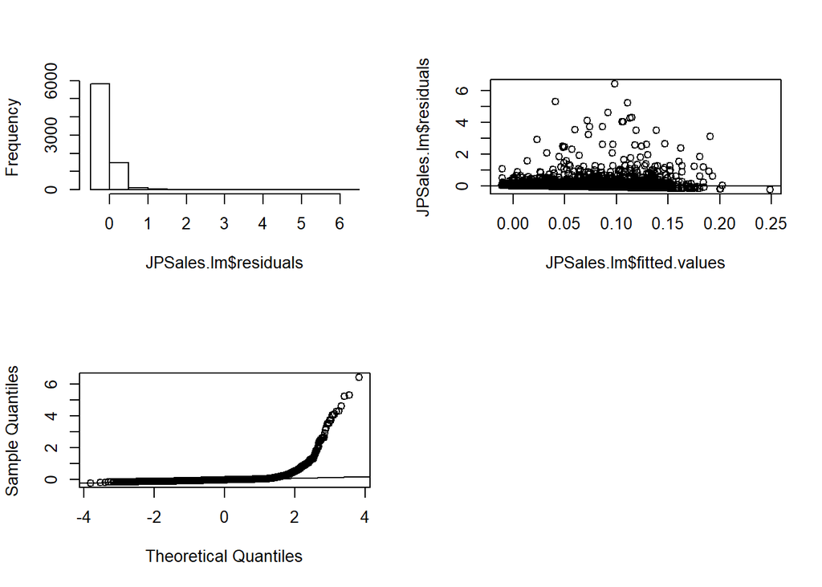

```r
#Assessing Model Conditions
par(mfrow = c(2,2))
hist(JPSales.lm$residuals, main=NULL)

plot(JPSales.lm$fitted.values, JPSales.lm$residuals)
abline(h=0)

qqnorm(JPSales.lm$residuals, main=NULL)
qqline(JPSales.lm$residuals)
par(mfrow = c(1,1))
```

```r
# Transforming the data
squrtJP = sqrt(JP_Sales)

TransJP.lm = lm(squrtJP ~ Year_of_Release + User_Score + I(User_Score^2) + I(Year_of_Release^2))
summary(TransJP.lm)
```

```
##
## Call:
## lm(formula = squrtJP ~ Year_of_Release + User_Score + I(User_Score^2) +
##     I(Year_of_Release^2))
##
## Residuals:
##      Min       1Q   Median       3Q      Max
## -0.27250 -0.11515 -0.06314  0.00483  2.41161
##
## Coefficients:
##                        Estimate Std. Error t value Pr(>|t|)
## (Intercept)           2.555e+03  4.658e+02   5.486 4.24e-08 ***
## Year_of_Release      -2.549e+00  4.640e-01  -5.494 4.05e-08 ***
## User_Score           -4.141e-02  9.734e-03  -4.254 2.12e-05 ***
## I(User_Score^2)       5.847e-03  7.811e-04   7.486 7.93e-14 ***
## I(Year_of_Release^2)  6.358e-04  1.155e-04   5.503 3.86e-08 ***
## ---
## Signif. codes:  0 '***' 0.001 '**' 0.01 '*' 0.05 '.' 0.1 ' ' 1
##
## Residual standard error: 0.2184 on 7458 degrees of freedom
##   (127 observations deleted due to missingness)
## Multiple R-squared:  0.05078,    Adjusted R-squared:  0.05028
## F-statistic: 99.75 on 4 and 7458 DF,  p-value: < 2.2e-16
```

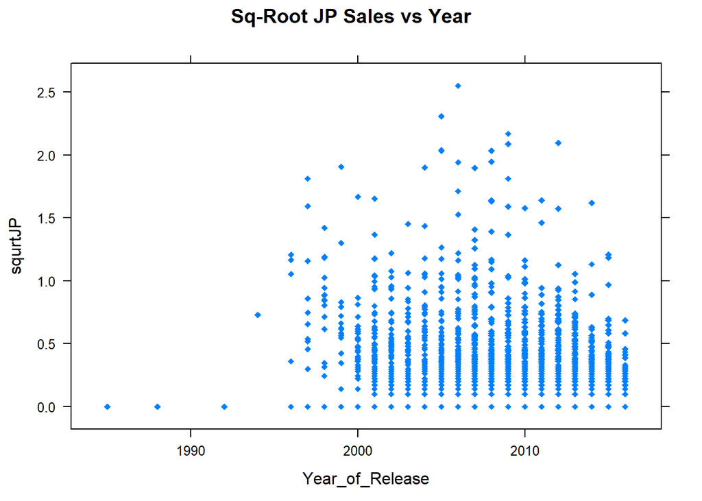

```r
xyplot(squrtJP ~ Year_of_Release, main="Sq-Root JP Sales vs Year", pch = 18)
```

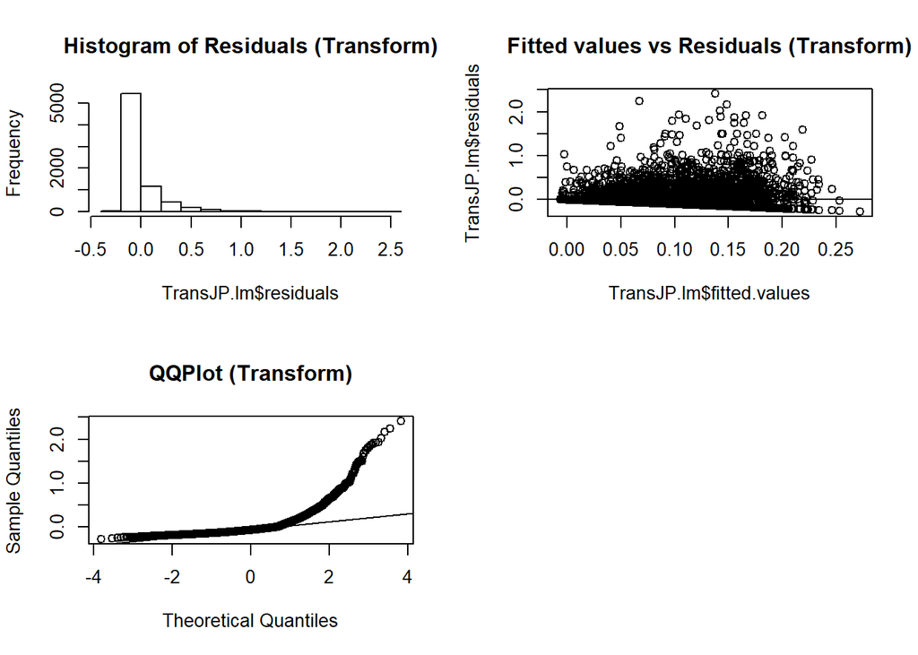

```r
#Assessing Model Conditions Again
par(mfrow = c(2,2))

hist(TransJP.lm$residuals, main="Histogram of Residuals (Transform)")

plot(TransJP.lm$fitted.values, TransJP.lm$residuals, main = "Fitted values vs Residuals (Transform)")
abline(h=0)

qqnorm(TransJP.lm$residuals, main="QQPlot (Transform)")
qqline(TransJP.lm$residuals)
par(mfrow = c(1,1))
```

```r
detach(analysis_1)
```

Conclusion: The year of release and User Score of games do have a relationship with the number of sales in Japan. However, I cannot say this with complete certainty, as the model only explains 5.1% of the variability.

```
The model assumptions are also violated. My QQPlot with my original data shows more extreme values than we would expect at one of its ends. The Fits/Residuals plot is also clumped around a certain side of the zero line. I tried every transform on each one of the variables separately and together, and I saw that a square root transform of the Sales worked the best, as the histogram showed a slightly more normal distribution, and the Fits vs Residuals are also a bit more varied around zero. The assumptions were still not met though.
```

#### 2. ANOVA Question (EX - C, RESP - Q)

How does the user score change with the game genre?

Explanatory - Genre  
Response - User_Score

There are more than 2 groups (about 12 levels), so a two-sampled t-test does not work out for us. An ANOVA test would be appropriate!

MODEL:
$$Y = \mu + \alpha_i + \epsilon$$
$$Y = \text{User Score}, \alpha_i = \text{Genre Group Effect}$$

```r
analysis_2 <- Original_Dataset[!(is.na(Original_Dataset$User_Score)),]

# Use Genre as Factor
analysis_2$Genre <- as.factor(analysis_2$Genre)
analysis_2$Developer <- as.character(analysis_2$Developer)
analysis_2$Rating <- as.factor(analysis_2$Rating)

attach(analysis_2)
levels(Genre)
```

```
##  [1] "Action"       "Adventure"    "Fighting"     "Misc"
##  [5] "Platform"     "Puzzle"       "Racing"       "Role-Playing"
##  [9] "Shooter"      "Simulation"   "Sports"       "Strategy"
```

```r
levels(Rating)
```

```
## [1] "AO"   "E"    "E10+" "EC"   "K-A"  "M"    "RP"   "T"
```

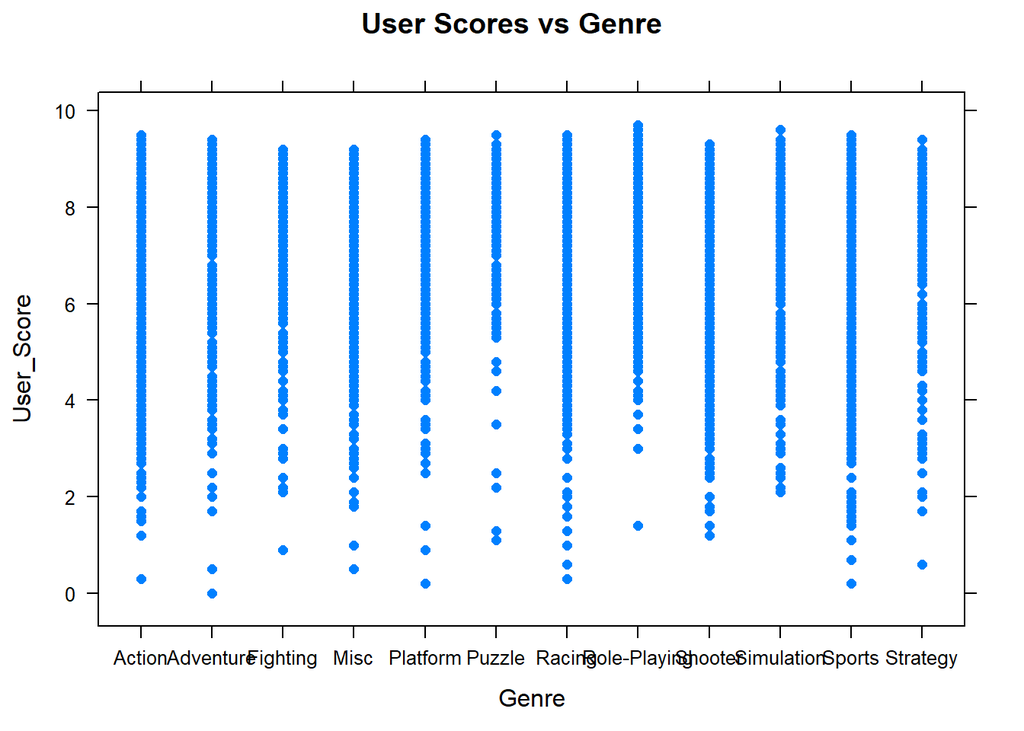

```r
xyplot(User_Score ~ Genre, main="User Scores vs Genre", pch=16)
```

```r
UserScore.aov = aov(User_Score ~ Genre)
summary(UserScore.aov)
```

```
##               Df Sum Sq Mean Sq F value Pr(>F)
## Genre         11    308  28.020   12.66 <2e-16 ***
## Residuals   7578  16767   2.213
## ---
## Signif. codes:  0 '***' 0.001 '**' 0.01 '*' 0.05 '.' 0.1 ' ' 1
```

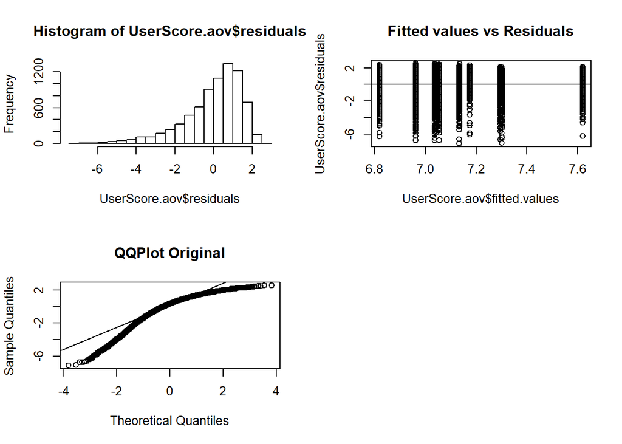

```r
### Check Model Assumptions ###
par(mfrow = c(2,2))
hist(UserScore.aov$residuals)

plot(UserScore.aov$fitted.values, UserScore.aov$residuals, main = "Fitted values vs Residuals")
abline(h=0)

qqnorm(UserScore.aov$residuals, main = "QQPlot Original")
qqline(UserScore.aov$residuals)
par(mfrow = c(1,1))
```

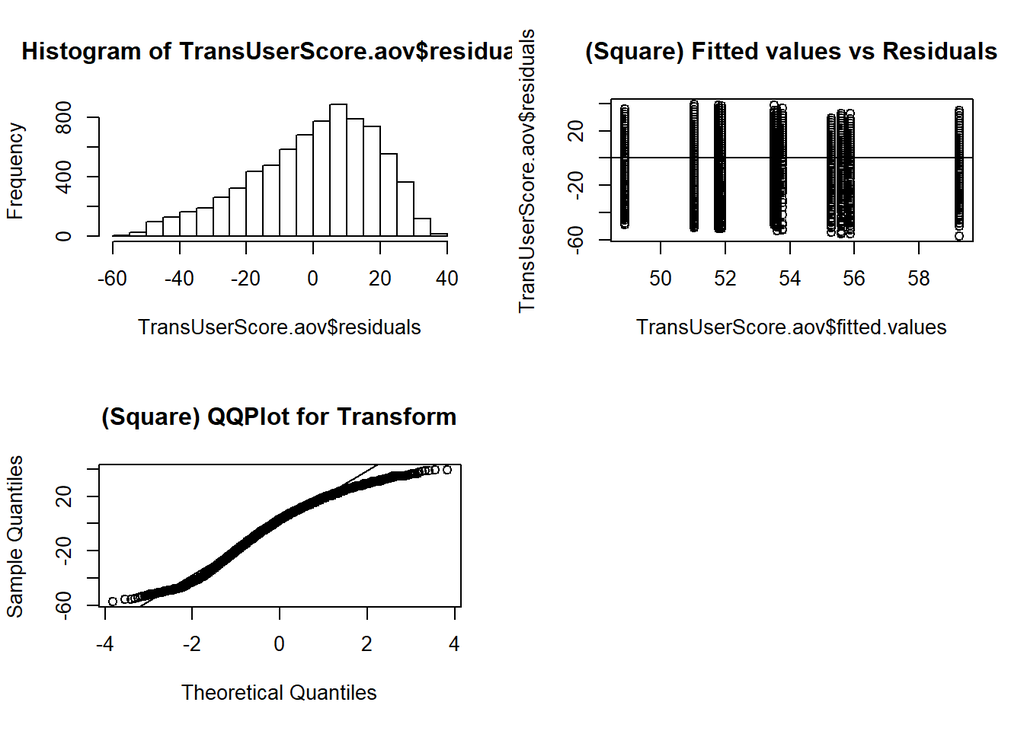

```r
# Transformation
score_sq = User_Score^2
TransUserScore.aov = aov(score_sq ~ Genre)

par(mfrow = c(2,2))
hist(TransUserScore.aov$residuals)
plot(TransUserScore.aov$fitted.values, TransUserScore.aov$residuals, main = "(Square) Fitted values vs Residuals")
abline(h=0)
qqnorm(TransUserScore.aov$residuals, main = "(Square) QQPlot for Transform")
qqline(TransUserScore.aov$residuals)
par(mfrow = c(1,1))
```

```r
summary(TransUserScore.aov)
```

```
##               Df  Sum Sq Mean Sq F value Pr(>F)
## Genre         11   52966    4815   13.81 <2e-16 ***
## Residuals   7578 2641746     349
## ---
## Signif. codes:  0 '***' 0.001 '**' 0.01 '*' 0.05 '.' 0.1 ' ' 1
```

We know that the User Scores vary significantly with each group, but how are the groups different?

```r
# Which groups are significantly different?
#FisherTest - LSD.test(Response, Explanatory, df-resid, meansq-resid)
fisher <- LSD.test(score_sq, Genre, 7578, 349)
fisher
```

```
## $statistics
##   MSerror   Df   Mean       CV
##       349 7578 53.016 35.23755
##
## $parameters
##         test p.ajusted name.t ntr alpha
##   Fisher-LSD      none  Genre  12  0.05
##
## $means
##              score_sq      std    r      LCL      UCL  Min   Max     Q25
## Action       51.79017 18.11914 1830 50.93411 52.64623 0.09 90.25 39.6900
## Adventure    53.61170 20.00268  300 51.49739 55.72601 0.00 88.36 40.9600
## Fighting     55.28910 17.88536  399 53.45575 57.12244 0.81 84.64 43.5600
## Misc         48.89210 18.81889  439 47.14427 50.63992 0.25 84.64 36.0000
## Platform     55.59617 19.34200  428 53.82603 57.36631 0.04 88.36 43.2325
## Puzzle       53.77219 18.54421  128 50.53532 57.00906 1.21 90.25 40.6425
## Racing       51.89598 19.22586  641 50.44953 53.34242 0.09 90.25 38.4400
## Role-Playing 59.24066 15.34678  743 57.89717 60.58415 1.96 94.09 50.4100
## Shooter      51.89021 18.79057  924 50.68546 53.09495 1.44 86.49 39.6900
## Simulation   53.52404 20.21173  344 51.54957 55.49851 4.41 92.16 42.2500
## Sports       51.05242 19.84252 1103 49.94976 52.15508 0.04 90.25 37.2100
## Strategy     55.88167 20.04563  311 53.80509 57.95826 0.36 88.36 46.2400
##                Q50     Q75
## Action       54.76 65.6100
## Adventure    57.76 67.6525
## Fighting     57.76 68.8900
## Misc         50.41 64.0000
## Platform     59.29 70.9825
## Puzzle       56.25 67.2400
## Racing       54.76 67.2400
## Role-Playing 60.84 70.5600
## Shooter      54.76 65.6100
## Simulation   56.25 68.8900
## Sports       54.76 65.6100
## Strategy     60.84 70.5600
##
## $comparison
## NULL
##
## $groups
##              score_sq groups
## Role-Playing 59.24066      a
## Strategy     55.88167      b
## Platform     55.59617      b
## Fighting     55.28910      b
## Puzzle       53.77219     bc
## Adventure    53.61170     bc
## Simulation   53.52404     bc
## Racing       51.89598      c
## Shooter      51.89021      c
## Action       51.79017      c
## Sports       51.05242      c
## Misc         48.89210      d
##
## attr(,"class")
## [1] "group"
```

```r
# Tukey
TukeyHSD(TransUserScore.aov)
```

```
##   Tukey multiple comparisons of means
##     95% family-wise confidence level
##
## Fit: aov(formula = score_sq ~ Genre)
##
## $Genre
##                                 diff           lwr        upr     p adj
## Adventure-Action         1.821530601  -1.980288093  5.6233493 0.9211571
## Fighting-Action          3.498928345   0.126592538  6.8712642 0.0339108
## Misc-Action             -2.898073727  -6.141822532  0.3456751 0.1336852
## Platform-Action          3.805998825   0.528803613  7.0831940 0.0081668
## Puzzle-Action            1.982018101  -3.598359494  7.5623957 0.9916839
## Racing-Action            0.105805640  -2.695558631  2.9071699 1.0000000
## Role-Playing-Action      7.450490090   4.795348328 10.1056319 0.0000000
## Shooter-Action           0.100036229  -2.363212174  2.5632846 1.0000000
## Simulation-Action        1.733871299  -1.852975075  5.3207177 0.9164633
## Sports-Action           -0.737748728  -3.064395759  1.5888983 0.9968699
## Strategy-Action          4.091502627   0.347894628  7.8351106 0.0184168
## Fighting-Adventure       1.677397744  -2.986825028  6.3416205 0.9907744
## Misc-Adventure          -4.719604328  -9.291718892 -0.1474898 0.0358596
## Platform-Adventure       1.984468224  -2.611435793  6.5803722 0.9615712
## Puzzle-Adventure         0.160487500  -6.283342058  6.6043171 1.0000000
## Racing-Adventure        -1.715724961  -5.985381511  2.5539316 0.9775629
## Role-Playing-Adventure   5.628959489   1.453782480  9.8041365 0.0006514
## Shooter-Adventure       -1.721494372  -5.777344217  2.3343555 0.9661035
## Simulation-Adventure    -0.087659302  -4.909255737  4.7339371 1.0000000
## Sports-Adventure        -2.559279329  -6.533648673  1.4150900 0.6191508
## Strategy-Adventure       2.269972026  -2.669352435  7.2092965 0.9403401
## Misc-Fighting           -6.397002072 -10.618738090 -2.1752661 0.0000477
## Platform-Fighting        0.307070480  -3.940417854  4.5545588 1.0000000
## Puzzle-Fighting         -1.516910244  -7.717052403  4.6832319 0.9997195
## Racing-Fighting         -3.393122705  -7.285267419  0.4990220 0.1595975
## Role-Playing-Fighting    3.951561744   0.163300076  7.7398234 0.0319561
## Shooter-Fighting        -3.398892117  -7.055221065  0.2574368 0.0977251
## Simulation-Fighting     -1.765057047  -6.255782556  2.7256685 0.9811064
## Sports-Fighting         -4.236677073  -7.802407727 -0.6709464 0.0058381
## Strategy-Fighting        0.592574281  -4.024323978  5.2094725 0.9999996
## Platform-Misc            6.704072552   2.557940057 10.8502050 0.0000084
## Puzzle-Misc              4.880091828  -1.251059802 11.0112435 0.2784936
## Racing-Misc              3.003879367  -0.777396607  6.7851553 0.2813643
```

[output cut: 18 more lines]

```
## Role-Playing-Racing      7.344684450   4.054407949 10.6349610 0.0000000
## Shooter-Racing          -0.005769411  -3.143242019  3.1317032 1.0000000
## Simulation-Racing        1.628065659  -2.451347116  5.7074784 0.9787211
## Sports-Racing           -0.843554368  -3.874961316  2.1878526 0.9990457
## Strategy-Racing          3.985696987  -0.232210377  8.2036044 0.0850011
## Shooter-Role-Playing    -7.350453861 -10.358089205 -4.3428185 0.0000000
## Simulation-Role-Playing -5.716618791  -9.697038942 -1.7361986 0.0001711
## Sports-Role-Playing     -8.188238818 -11.085058466 -5.2914192 0.0000000
## Strategy-Role-Playing   -3.358987463  -7.481229392  0.7632545 0.2447408
## Simulation-Shooter       1.633835070  -2.221234254  5.4889044 0.9664743
## Sports-Shooter          -0.837784957  -3.559802406  1.8842325 0.9975998
## Strategy-Shooter         3.991466398  -0.009870058  7.9928029 0.0512542
## Sports-Simulation       -2.471620027  -6.240871041  1.2976310 0.5910539
## Strategy-Simulation      2.357631328  -2.418200291  7.1334629 0.9044514
## Strategy-Sports          4.829251355   0.910528712  8.7479740 0.0032896
```

```r
detach(analysis_2)
```

Conclusion: User Scores do vary by game genre. The relationship from the Fisher’s test can be summarized below.

| A | B | C | D |
| --- | --- | --- | --- |
| Role-Playing | Strategy | Puzzle | Misc |
|  | Platform | Adventure |  |
|  | Fighting | Simulation |  |
|  | Adventure | Racing |  |
|  | Simulation | Shooter |  |
|  | Puzzle | Action |  |
|  |  | Sports |  |

The model assumptions are not extremely well met, as the histogram does not show a very normal plot, and the QQPlot shows more extreme deviations than we would expect from a normal distribution at its ends. Transforming the data by squaring the User Score only helped a little.

#### 3. Logistic Regression Question (EX - Q, RESP - C)

Do critics give games different scores change before and after 2010? Is a highly critiqued game more likely to be before or after 2010?

Explanatory - Critic Score  
Response - Before and After 2010

MODEL:
$$\pi = \frac {e^{\beta_0 + \beta_1X }} {1 + e^{\beta_0 + \beta_1X }}$$
$$\pi = \text{P(1), Probability that game was made after 2010}, X = \text{Critic score}$$

```r
year = as.factor(analysis_2$Year_of_Release)
levels(year)
```

```
##  [1] "1985" "1988" "1992" "1994" "1996" "1997" "1998" "1999" "2000" "2001"
## [11] "2002" "2003" "2004" "2005" "2006" "2007" "2008" "2009" "2010" "2011"
## [21] "2012" "2013" "2014" "2015" "2016"
```

```r
table(year)
```

```
## year
## 1985 1988 1992 1994 1996 1997 1998 1999 2000 2001 2002 2003 2004 2005 2006
##    1    1    1    1    8   18   31   31  107  257  464  516  489  583  552
## 2007 2008 2009 2010 2011 2012 2013 2014 2015 2016
##  629  661  614  467  501  339  304  329  297  262
```

```r
After2010 = as.numeric(analysis_2$Year_of_Release > 2010) # 0 : <= 2010, 1 : > 2010
analysis_3 = analysis_2
analysis_3$After2010 = After2010
attach(analysis_3)
YearMade.lm = lm(After2010 ~ Critic_Score)
summary(YearMade.lm)
```

```
##
## Call:
## lm(formula = After2010 ~ Critic_Score)
##
## Residuals:
##     Min      1Q  Median      3Q     Max
## -0.3057 -0.2679 -0.2463  0.7069  0.8474
##
## Coefficients:
##               Estimate Std. Error t value Pr(>|t|)
## (Intercept)  0.1292399  0.0271079   4.768 1.90e-06 ***
## Critic_Score 0.0018003  0.0003785   4.756 2.01e-06 ***
## ---
## Signif. codes:  0 '***' 0.001 '**' 0.01 '*' 0.05 '.' 0.1 ' ' 1
##
## Residual standard error: 0.4356 on 6892 degrees of freedom
##   (696 observations deleted due to missingness)
## Multiple R-squared:  0.003271,   Adjusted R-squared:  0.003127
## F-statistic: 22.62 on 1 and 6892 DF,  p-value: 2.014e-06
```

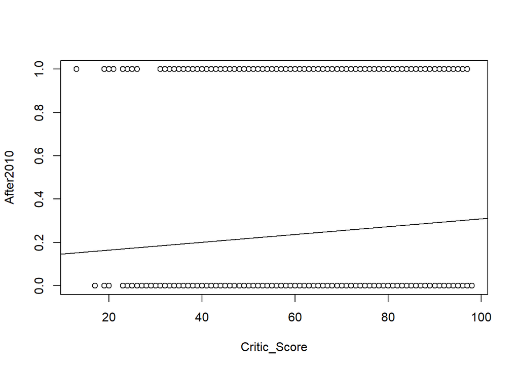

```r
plot(After2010 ~ Critic_Score, data = analysis_3)
abline(YearMade.lm)
```

```r
# Using a General Linear Model
YearGen.glm = glm(After2010 ~ Critic_Score, family=binomial, data = analysis_3)
summary(YearGen.glm)
```

```
##
## Call:
## glm(formula = After2010 ~ Critic_Score, family = binomial, data = analysis_3)
##
## Deviance Residuals:
##     Min       1Q   Median       3Q      Max
## -0.8605  -0.7891  -0.7502   1.5624   1.9020
##
## Coefficients:
##               Estimate Std. Error z value Pr(>|z|)
## (Intercept)  -1.756306   0.148696  -11.81  < 2e-16 ***
## Critic_Score  0.009729   0.002053    4.74 2.14e-06 ***
## ---
## Signif. codes:  0 '***' 0.001 '**' 0.01 '*' 0.05 '.' 0.1 ' ' 1
##
## (Dispersion parameter for binomial family taken to be 1)
##
##     Null deviance: 7839.1  on 6893  degrees of freedom
## Residual deviance: 7816.1  on 6892  degrees of freedom
##   (696 observations deleted due to missingness)
## AIC: 7820.1
##
## Number of Fisher Scoring iterations: 4
```

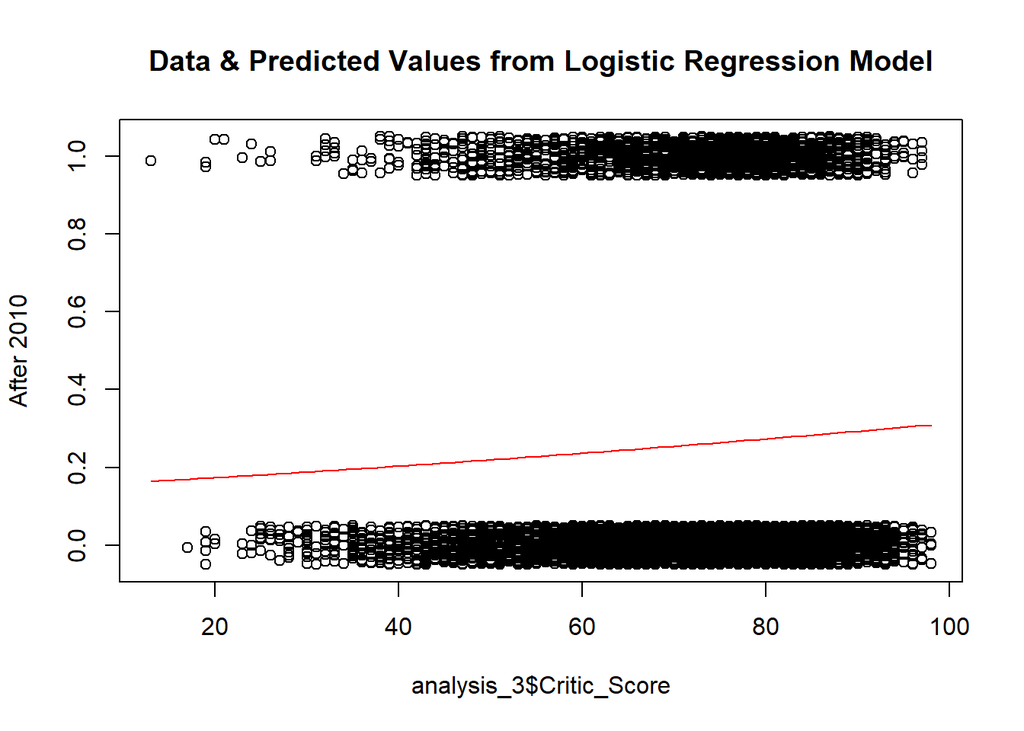

```r
b0 = YearGen.glm$coefficients[1] # intercept
b1 = YearGen.glm$coefficients[2] # slope
plot(analysis_3$Critic_Score, jitter(analysis_3$After2010,amount=.05),ylab="After 2010")
curve(exp(b0+b1*x)/(1+exp(b0+b1*x)),add=T,col="red")
title(main="Data & Predicted Values from Logistic Regression Model")
```

To see the R code that generated this webpage, you can see it at my Github page:

[See Code on Github](https://github.com/Emmaloto/rstudio-projects)

[My Website](https://icyblaze16.wixsite.com/emmaloto/programming-projects)